# Homework #2

Get dataset with region data from GitHub:

```r
linkRegions= 'https://github.com/efweavs1989/PUBPOL599B_DATA/blob/master/hh_sec_a.csv?raw=true'
region=read.csv(linkRegions)
region
```

| occ | y4_hhid | hh_a06 | hh_a13 | y4_rural | domain | strataid | clusterid | wardtype | clustertype | y4_weights | hh_a01_1 | hh_a01_2 | hh_a02_1 | hh_a02_2 | hh_a03_1 | hh_a03_2 | hh_a03_3a | hh_a03_3b | hh_a04_1 | hh_a04_2 | hh_a05 | hh_a07_1 | hh_a07_2 | hh_a08 | hh_a09 | hh_a10 | hh_a11 | hh_a12_2 | hh_a12_1 | … |
| --- | --- | --- | --- | --- | --- | --- | --- | --- | --- | --- | --- | --- | --- | --- | --- | --- | --- | --- | --- | --- | --- | --- | --- | --- | --- | --- | --- | --- | --- | --- |
| 1 | 1000-001 | 1000 | 1 | NA | 3 | 4 | 20203304004 | 3 | 1 | 3755.7251 | 2 | ARUSHA | 2 | MERU | 33 | **CONFIDENTIAL** | 4 | KOLILA | 4 | **CONFIDENTIAL** | **CONFIDENTIAL** | **CONFIDENTIAL** | 2 | NA | NA | NA | NA | NA | NA | … |
| 1 | 1001-001 | 1001 | 1 | NA | 3 | 4 | 20203304004 | 3 | 1 | 3755.7251 | 2 | ARUSHA | 2 | MERU | 33 | **CONFIDENTIAL** | 4 | KOLILA | 4 | **CONFIDENTIAL** | **CONFIDENTIAL** | **CONFIDENTIAL** | 2 | NA | NA | NA | NA | NA | NA | … |
| 1 | 1002-001 | 1002 | 1 | NA | 3 | 4 | 20203304004 | 3 | 1 | 3755.7251 | 2 | ARUSHA | 2 | MERU | 33 | **CONFIDENTIAL** | 4 | KOLILA | 4 | **CONFIDENTIAL** | **CONFIDENTIAL** | **CONFIDENTIAL** | 2 | NA | NA | NA | NA | NA | NA | … |
| 1 | 1003-001 | 1003 | 1 | NA | 3 | 4 | 20203304004 | 3 | 1 | 3755.7251 | 2 | ARUSHA | 2 | MERU | 33 | **CONFIDENTIAL** | 4 | KOLILA | 4 | **CONFIDENTIAL** | **CONFIDENTIAL** | **CONFIDENTIAL** | 2 | NA | NA | NA | NA | NA | NA | … |
| 1 | 1005-001 | 1005 | 1 | NA | 3 | 4 | 20203304004 | 3 | 1 | 3755.7251 | 2 | ARUSHA | 2 | MERU | 33 | **CONFIDENTIAL** | 4 | KOLILA | 4 | **CONFIDENTIAL** | **CONFIDENTIAL** | **CONFIDENTIAL** | 2 | NA | NA | NA | NA | NA | NA | … |
| 1 | 1006-001 | 1006 | 1 | NA | 3 | 4 | 20203304004 | 3 | 1 | 3755.7251 | 2 | ARUSHA | 2 | MERU | 33 | **CONFIDENTIAL** | 4 | KOLILA | 4 | **CONFIDENTIAL** | **CONFIDENTIAL** | **CONFIDENTIAL** | 2 | NA | NA | NA | NA | NA | NA | … |
| 1 | 1007-001 | 1007 | 1 | NA | 3 | 4 | 20203304004 | 3 | 1 | 3755.7251 | 2 | ARUSHA | 2 | MERU | 33 | **CONFIDENTIAL** | 4 | KOLILA | 4 | **CONFIDENTIAL** | **CONFIDENTIAL** | **CONFIDENTIAL** | 2 | NA | NA | NA | NA | NA | NA | … |
| 1 | 1009-001 | 1009 | 1 | NA | 3 | 4 | 20203304004 | 3 | 1 | 3755.7251 | 2 | ARUSHA | 2 | MERU | 33 | **CONFIDENTIAL** | 4 | KOLILA | 4 | **CONFIDENTIAL** | **CONFIDENTIAL** | **CONFIDENTIAL** | 2 | NA | NA | NA | NA | NA | NA | … |
| 1 | 1019-001 | 1019 | 1 | NA | 2 | 3 | 20210303304 | 3 | 2 | 5792.7812 | 2 | ARUSHA | 2 | MERU | 103 | **CONFIDENTIAL** | 3 | USA RIVER | 304 | **CONFIDENTIAL** | **CONFIDENTIAL** | **CONFIDENTIAL** | 2 | NA | NA | NA | NA | NA | NA | … |
| 1 | 1020-001 | 1020 | 1 | NA | 2 | 3 | 20210303304 | 3 | 2 | 5792.7812 | 2 | ARUSHA | 2 | MERU | 103 | **CONFIDENTIAL** | 3 | USA RIVER | 304 | **CONFIDENTIAL** | **CONFIDENTIAL** | **CONFIDENTIAL** | 2 | NA | NA | NA | NA | NA | NA | … |

[output cut: 990 more lines]

Get dataset with Section I data from Github:

```r
i_link= 'https://github.com/efweavs1989/PUBPOL599B_DATA/raw/master/hh_sec_i.csv'
i_data= read.csv(i_link)
```

Get dataset with Section Q1 data from Github:

```r
q1_link= 'https://github.com/efweavs1989/PUBPOL599B_DATA/raw/master/hh_sec_q1.csv'
q1_data= read.csv(q1_link)
```

View names to identify which variables we need to keep and keep household ID, region number, and region name:

```r
names(region)
```

```
 [1] "occ"         "y4_hhid"     "hh_a06"      "hh_a13"      "y4_rural"
 [6] "domain"      "strataid"    "clusterid"   "wardtype"    "clustertype"
[11] "y4_weights"  "hh_a01_1"    "hh_a01_2"    "hh_a02_1"    "hh_a02_2"
[16] "hh_a03_1"    "hh_a03_2"    "hh_a03_3a"   "hh_a03_3b"   "hh_a04_1"
[21] "hh_a04_2"    "hh_a05"      "hh_a07_1"    "hh_a07_2"    "hh_a08"
[26] "hh_a09"      "hh_a10"      "hh_a11"      "hh_a12_2"    "hh_a12_1"
[31] "hh_a14"      "hh_a15"      "hh_a16"      "hh_a17_1"    "hh_a17_2"
[36] "hh_a18"      "hh_a18_1"    "hh_a18_2"    "hh_a18_3"    "hh_a19"
[41] "hh_a20"      "hh_a21"      "hh_a21_1"    "hh_a21_2"    "hh_a21_3"
[46] "hh_a22"      "hh_a23"      "hh_a24"      "hh_a24_1"    "hh_a24_2"
[51] "hh_a24_3"    "hh_a25"      "hh_a26"      "hh_a26_1"    "hh_a26_2"
[56] "hh_a26_3"    "hh_a27"
```

```r
region=region[,c("y4_hhid","hh_a01_1", "hh_a01_2")]
```

View names for Section I data to determine which we need to keep:

```r
names(i_data)
```

```
 [1] "occ"      "y4_hhid"  "hh_i01"   "hh_i02"   "hh_i03"   "hh_i04"
 [7] "hh_i05"   "hh_i06"   "hh_i07_1" "hh_i07_2" "hh_i08"   "hh_i09"
[13] "hh_i10"   "hh_i11"   "hh_i12"   "hh_i13"   "hh_i14"   "hh_i15"
[19] "hh_i16"   "hh_i17"   "hh_i18"   "hh_i19"   "hh_i20"   "hh_i21"
[25] "hh_i22"   "hh_i23"   "hh_i24_1" "hh_i24_2" "hh_i25"   "hh_i26"
[31] "hh_i27"   "hh_i28"   "hh_i29"   "hh_i30"   "hh_i31"   "hh_i32"
[37] "hh_i33"   "hh_i34_1" "hh_i34_2" "hh_i35"   "hh_i36"
```

Select variables from Section I that want to anlayze. These are:

“hh_i05”: In the past year, how much have you paid on repairs to your dwelling? (TSH) “hh_i06”: In the past year, how much have you paid in improvements to your home (excluding any purchases listed in previous question)? (TSH) “hh_i08”: The walls of the main dwelling are predominantly made of what materials? (See questionnaire for options) “hh_i09”: The roof of the main dwelling is predominantly made of what materials? (See questionnaire for options) “hh_i10”: The floor of the main dwelling is predominantly made of what materials? (See questionnaire for options)

```r
i_data=i_data[,c("y4_hhid","hh_i05","hh_i06","hh_i08","hh_i09","hh_i10")]
```

View names from Section Q1 data to determine which names we need to keep:

```r
names(q1_data)
```

```
 [1] "occ"      "y4_hhid"  "hh_q01_1" "hh_q01_2" "hh_q01_3" "hh_q01_4"
 [7] "hh_q02"   "hh_q03_a" "hh_q03_b" "hh_q03_c" "hh_q03_d" "hh_q03_e"
[13] "hh_q03_f" "hh_q03_g" "hh_q03_h" "hh_q04"   "hh_q05_1" "hh_q05_2"
[19] "hh_q06"   "hh_q07"   "hh_q08"   "hh_q09_1" "hh_q09_2" "hh_q09_3"
[25] "hh_q10"   "hh_q11_1" "hh_q11_2" "hh_q11_3" "hh_q12"   "hh_q13_1"
[31] "hh_q13_2" "hh_q13_3" "hh_q14"
```

Select variables from Section Q that want to anlayze. These are:

“hh_q01_1”: Did you or anyone in your household use M-PESA to transfer money over the last 12 months “hh_q01_2”: Did you or anyone in your household use EZY PESA to transfer money over the last 12 months “hh_q01_3”: Did you or anyone in your household use Airtel Money to transfer money over the last 12 months “hh_q01_4”: Did you or anyone in your household use TIGO PESA to transfer money over the last 12 months

```r
q1_data=q1_data[,c("y4_hhid","hh_q01_1","hh_q01_2","hh_q01_3","hh_q01_4")]
```

Merge data sets. Need to merge one by one.

```r
i_reg=merge(region,i_data)
projectData=merge(i_reg,q1_data)
```

Check the data type so know how to aggregate the data.

```r
str(projectData)
```

```
'data.frame':   3352 obs. of  12 variables:
 $ y4_hhid : Factor w/ 3352 levels "1000-001","1001-001",..: 1 2 3 4 5 6 7 8 9 10 ...
 $ hh_a01_1: int  2 2 2 2 2 2 2 2 2 2 ...
 $ hh_a01_2: Factor w/ 30 levels "ARUSHA","DAR ES SALAAM",..: 1 1 1 1 1 1 1 1 1 1 ...
 $ hh_i05  : int  0 0 0 0 0 0 0 0 0 0 ...
 $ hh_i06  : int  0 0 350000 0 0 0 0 0 0 0 ...
 $ hh_i08  : int  4 4 6 4 4 2 2 5 6 5 ...
 $ hh_i09  : int  4 4 4 4 4 4 4 4 4 4 ...
 $ hh_i10  : int  1 2 2 1 2 1 1 2 2 2 ...
 $ hh_q01_1: int  1 2 2 2 1 1 1 1 2 1 ...
 $ hh_q01_2: int  2 2 2 2 2 2 2 2 2 2 ...
 $ hh_q01_3: int  1 2 2 2 2 2 2 2 2 2 ...
 $ hh_q01_4: int  2 2 2 2 2 2 2 2 2 2 ...
```

My primary variable is how much each household paid for improvements to their home in the past year (hh_i06). I start by finding the median of this variables for each region:

```r
aggregate(cbind(hh_i06) ~ hh_a01_1, data=projectData, FUN=median)
```

| hh_a01_1 | hh_i06 |
| --- | --- |
| 1 | 0 |
| 2 | 0 |
| 3 | 0 |
| 4 | 0 |
| 5 | 0 |
| 6 | 0 |
| 7 | 0 |
| 8 | 0 |
| 9 | 0 |
| 10 | 0 |

[output cut: 20 more lines]

To find better results I restrict my sample to households where improvments are made to the home (hh_i06 does not equal zero).

```r
projectData_res=projectData[projectData$hh_i06!=0,]
projectData_res
```

|  | y4_hhid | hh_a01_1 | hh_a01_2 | hh_i05 | hh_i06 | hh_i08 | hh_i09 | hh_i10 | hh_q01_1 | hh_q01_2 | hh_q01_3 | hh_q01_4 |
| --- | --- | --- | --- | --- | --- | --- | --- | --- | --- | --- | --- | --- |
| 3 | 1002-001 | 2 | ARUSHA | 0 | 350000 | 6 | 4 | 2 | 2 | 2 | 2 | 2 |
| 21 | 1042-001 | 2 | ARUSHA | 0 | 147000 | 6 | 4 | 2 | 1 | 2 | 2 | 2 |
| 42 | 1096-001 | 2 | ARUSHA | 45000 | 11000 | 2 | 1 | 1 | 1 | 2 | 2 | 2 |
| 57 | 1133-001 | 7 | DAR ES SALAAM | 0 | 10000 | 6 | 4 | 2 | 2 | 2 | 2 | 1 |
| 80 | 1179-001 | 7 | DAR ES SALAAM | 0 | 300000 | 6 | 4 | 2 | 1 | 2 | 1 | 1 |
| 81 | 1191-001 | 7 | DAR ES SALAAM | 0 | 50000 | 6 | 4 | 2 | 1 | 2 | 1 | 1 |
| 90 | 1210-001 | 7 | DAR ES SALAAM | 0 | 2600000 | 6 | 4 | 2 | 2 | 2 | 2 | 1 |
| 96 | 1217-001 | 7 | DAR ES SALAAM | 1300000 | 150000 | 6 | 4 | 1 | 1 | 2 | 2 | 1 |
| 100 | 1232-001 | 7 | DAR ES SALAAM | 400000 | 400000 | 6 | 4 | 2 | 1 | 2 | 1 | 1 |
| 101 | 1233-001 | 7 | DAR ES SALAAM | 0 | 350000 | 6 | 4 | 2 | 1 | 1 | 1 | 1 |

[output cut: 254 more lines]

Check the data type now that we have restricted the data:

```r
str(projectData_res)
```

```
'data.frame':   264 obs. of  12 variables:
 $ y4_hhid : Factor w/ 3352 levels "1000-001","1001-001",..: 3 21 42 57 80 81 90 96 100 101 ...
 $ hh_a01_1: int  2 2 2 7 7 7 7 7 7 7 ...
 $ hh_a01_2: Factor w/ 30 levels "ARUSHA","DAR ES SALAAM",..: 1 1 1 2 2 2 2 2 2 2 ...
 $ hh_i05  : int  0 0 45000 0 0 0 0 1300000 400000 0 ...
 $ hh_i06  : int  350000 147000 11000 10000 300000 50000 2600000 150000 400000 350000 ...
 $ hh_i08  : int  6 6 2 6 6 6 6 6 6 6 ...
 $ hh_i09  : int  4 4 1 4 4 4 4 4 4 4 ...
 $ hh_i10  : int  2 2 1 2 2 2 2 1 2 2 ...
 $ hh_q01_1: int  2 1 1 2 1 1 2 1 1 1 ...
 $ hh_q01_2: int  2 2 2 2 2 2 2 2 2 1 ...
 $ hh_q01_3: int  2 2 2 2 1 1 2 2 1 1 ...
 $ hh_q01_4: int  2 2 2 1 1 1 1 1 1 1 ...
```

Now find the median of the improvements for each region:

```r
(median_improvements=aggregate(cbind(hh_i06) ~ hh_a01_1, data=projectData_res, FUN=median))
```

| hh_a01_1 | hh_i06 |
| --- | --- |
| 1 | 60000 |
| 2 | 248500 |
| 3 | 750000 |
| 4 | 78000 |
| 5 | 125000 |
| 6 | 15000 |
| 7 | 300000 |
| 8 | 20000 |
| 9 | 40000 |
| 10 | 50000 |

[output cut: 19 more lines]

And the mean of the improvements for each region:

```r
(mean_improvements=aggregate(cbind(hh_i06) ~ hh_a01_1, data=projectData_res, FUN=mean))
```

| hh_a01_1 | hh_i06 |
| --- | --- |
| 1 | 456055.56 |
| 2 | 377000.00 |
| 3 | 947375.00 |
| 4 | 420250.00 |
| 5 | 219666.67 |
| 6 | 72333.33 |
| 7 | 671696.97 |
| 8 | 53333.33 |
| 9 | 361846.15 |
| 10 | 233400.00 |

[output cut: 19 more lines]

Now find the standard deviation:

```r
sd(median_improvements$hh_i06,na.rm = T)
```

```
[1] 146482.7
```

```r
sd(mean_improvements$hh_i06,na.rm = T)
```

```
[1] 272013.9
```

and the coefficient of variation:

```r
sd(median_improvements$hh_i06,na.rm = T)/mean(median_improvements$hh_i06,na.rm = T)
```

```
[1] 1.004683
```

Skewness:

```r
library(moments)
skewness(median_improvements$hh_i06,na.rm = T)
```

```
[1] 2.508234
```

Kurtosis:

```r
kurtosis(median_improvements$hh_i06,na.rm = T)
```

```
[1] 10.97893
```

Now plot:

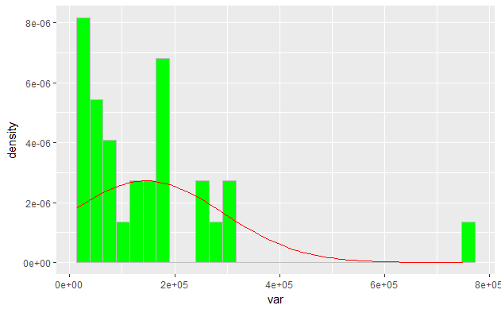

```r
library(ggplot2)
# keeping non missing:
data=median_improvements[is.finite(median_improvements$hh_i06),]
#
# selecting a var:
var=data$hh_i06
#
# saving mean and sd:
mnVar=mean(var,na.rm = T)
sdVar=sd(var,na.rm = T)
#
#plotting
base = ggplot(data, aes(x=var))
hist = base + geom_histogram(fill="green",
                             color='grey',
                          aes(y=..density..))
#
histAndNormal = hist + stat_function(fun=dnorm,
                                     color="red",
                                     args=list(mean=mnVar,sd=sdVar))
#
histAndNormal
```

Bivariate analysis: I will explore hh_i06 in relation to hh_i05, another numeric variable that looks at how much a household spends on repairs.

Compute the correlation:

```r
res <- cor(projectData_res[,c(4:5)],use='complete.obs')
round(res, 2)
```

```
       hh_i05 hh_i06
hh_i05   1.00   0.04
hh_i06   0.04   1.00
```

Compute correlation again with hh_i06 not restricted:

```r
res <- cor(projectData[,c(4:5)],use='complete.obs')
round(res, 2)
```

```
       hh_i05 hh_i06
hh_i05   1.00   0.02
hh_i06   0.02   1.00
```

Visual representation of the correlation:

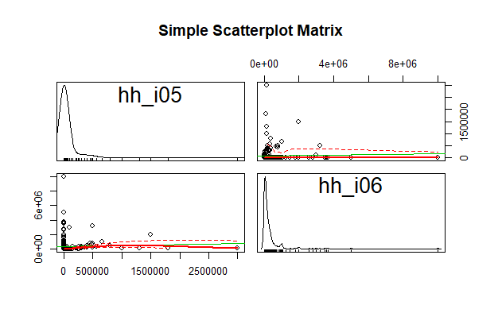

```r
library(car)
scatterplotMatrix(projectData_res[,c(4:5)],
   main="Simple Scatterplot Matrix")
```

Next explore the relationship between my main variable and “hh_i10”: The floor of the main dwelling is predominantly made of what materials? (See questionnaire for options)

```r
tapply(projectData_res$hh_i06, list(hh_i10=projectData_res$hh_i10), mean)
```

```
hh_i10
       1        2        3
170252.2 533734.7 600000.0
```

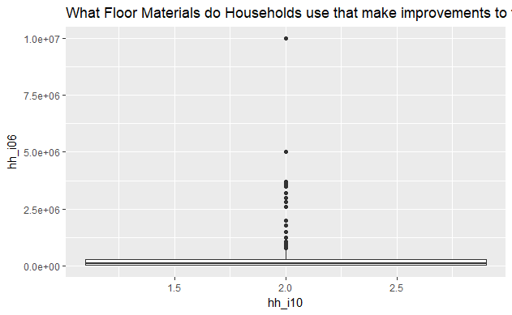

```r
projectData_res=projectData_res[complete.cases(projectData_res),] #excluding NA
p <- ggplot(projectData_res, aes(hh_i10,hh_i06))
#Professor Magallanes, I am using the function you provided for comparing categorical and numberical variables, but I am running into a few issues. I will come to office hours on Tuesday to go over this issue and try to better understand what ggplot is doing.
p + geom_boxplot() + labs(title="What Floor Materials do Households use that make improvements to their household?")
```